# ex7.2

Manuela Giansante

2022-11-02

# Exercise 2 Homework 2

we clean the environment and call for the needed libraries:

```r
rm(list = ls())
library(data.table) # to read the data
library(naniar) # to investigate missing values
library(caret) # to partition data
library(reshape2) #to reshape data from wide to long and back
library(kableExtra) # to build tables
library(FNN) #package for the naive bayes function
```

```r
setwd("C:/Users/Manu/Desktop/master course/data mining/data")
df <- fread("UniversalBank.csv") #import the dataset
df<- as.data.frame(df) # we apply this because the chuck goes into error otherwise, we will need to rename some variables as well
str(df) #structure of the dataset
```

```
## 'data.frame':    5000 obs. of  14 variables:
##  $ ID                : int  1 2 3 4 5 6 7 8 9 10 ...
##  $ Age               : int  25 45 39 35 35 37 53 50 35 34 ...
##  $ Experience        : int  1 19 15 9 8 13 27 24 10 9 ...
##  $ Income            : int  49 34 11 100 45 29 72 22 81 180 ...
##  $ ZIP Code          : int  91107 90089 94720 94112 91330 92121 91711 93943 90089 93023 ...
##  $ Family            : int  4 3 1 1 4 4 2 1 3 1 ...
##  $ CCAvg             : num  1.6 1.5 1 2.7 1 0.4 1.5 0.3 0.6 8.9 ...
##  $ Education         : int  1 1 1 2 2 2 2 3 2 3 ...
##  $ Mortgage          : int  0 0 0 0 0 155 0 0 104 0 ...
##  $ Personal Loan     : int  0 0 0 0 0 0 0 0 0 1 ...
##  $ Securities Account: int  1 1 0 0 0 0 0 0 0 0 ...
##  $ CD Account        : int  0 0 0 0 0 0 0 0 0 0 ...
##  $ Online            : int  0 0 0 0 0 1 1 0 1 0 ...
##  $ CreditCard        : int  0 0 0 0 1 0 0 1 0 0 ...
```

```r
summary(df) # main stats from the dataset
```

```
##        ID            Age          Experience       Income          ZIP Code
##  Min.   :   1   Min.   :23.00   Min.   :-3.0   Min.   :  8.00   Min.   : 9307
##  1st Qu.:1251   1st Qu.:35.00   1st Qu.:10.0   1st Qu.: 39.00   1st Qu.:91911
##  Median :2500   Median :45.00   Median :20.0   Median : 64.00   Median :93437
##  Mean   :2500   Mean   :45.34   Mean   :20.1   Mean   : 73.77   Mean   :93153
##  3rd Qu.:3750   3rd Qu.:55.00   3rd Qu.:30.0   3rd Qu.: 98.00   3rd Qu.:94608
##  Max.   :5000   Max.   :67.00   Max.   :43.0   Max.   :224.00   Max.   :96651
##      Family          CCAvg          Education        Mortgage
##  Min.   :1.000   Min.   : 0.000   Min.   :1.000   Min.   :  0.0
##  1st Qu.:1.000   1st Qu.: 0.700   1st Qu.:1.000   1st Qu.:  0.0
##  Median :2.000   Median : 1.500   Median :2.000   Median :  0.0
##  Mean   :2.396   Mean   : 1.938   Mean   :1.881   Mean   : 56.5
##  3rd Qu.:3.000   3rd Qu.: 2.500   3rd Qu.:3.000   3rd Qu.:101.0
##  Max.   :4.000   Max.   :10.000   Max.   :3.000   Max.   :635.0
##  Personal Loan   Securities Account   CD Account         Online
##  Min.   :0.000   Min.   :0.0000     Min.   :0.0000   Min.   :0.0000
##  1st Qu.:0.000   1st Qu.:0.0000     1st Qu.:0.0000   1st Qu.:0.0000
##  Median :0.000   Median :0.0000     Median :0.0000   Median :1.0000
##  Mean   :0.096   Mean   :0.1044     Mean   :0.0604   Mean   :0.5968
##  3rd Qu.:0.000   3rd Qu.:0.0000     3rd Qu.:0.0000   3rd Qu.:1.0000
##  Max.   :1.000   Max.   :1.0000     Max.   :1.0000   Max.   :1.0000
##    CreditCard
##  Min.   :0.000
##  1st Qu.:0.000
##  Median :0.000
##  Mean   :0.294
##  3rd Qu.:1.000
##  Max.   :1.000
```

```r
sapply(df, function(x) length(unique(x))) # unique length of the variables
```

```
##                 ID                Age         Experience             Income
##               5000                 45                 47                162
##           ZIP Code             Family              CCAvg          Education
##                467                  4                108                  3
##           Mortgage      Personal Loan Securities Account         CD Account
##                347                  2                  2                  2
##             Online         CreditCard
##                  2                  2
```

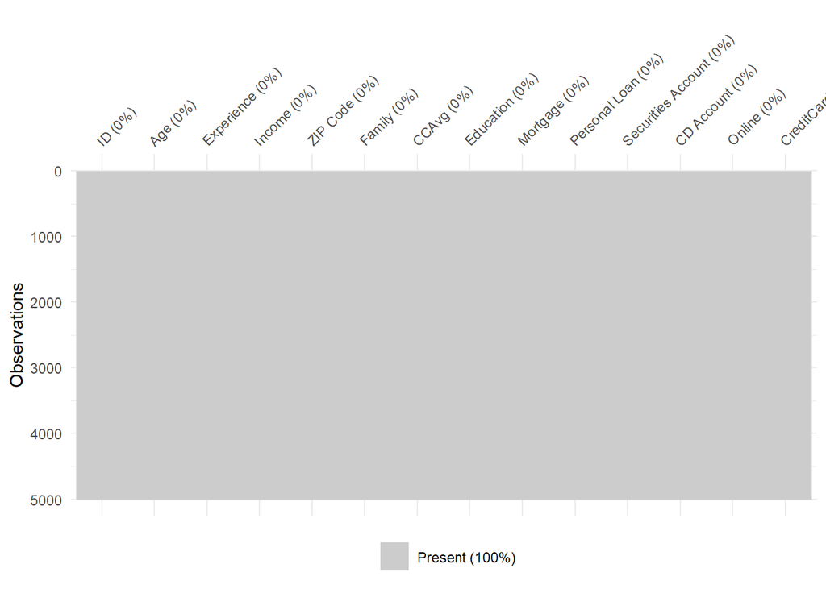

```r
vis_miss(df, warn_large_data =  FALSE) # we check for missing values - none
```

```r
colnames(df)[c(10:12)] <- c("Personal.Loan", "Sec.acc","CD.acc") # we change the names for practical reasons
summary(df$Mortgage==0) # we check the proportion of clients taking out mortgages
```

```
##    Mode   FALSE    TRUE
## logical    1538    3462
```

```r
summary(df$Personal.Loan==1) # how many borrowers
```

```
##    Mode   FALSE    TRUE
## logical    4520     480
```

We take a first look at the data, and we change the names of some variables for practical reasons. Education takes 3 different values, and it being a categorical value we can transform it into 3 dummy variables.The last 5 columns only take values 0,1 and we keep them as they are. The bank’s clients’ average age is around 45 years old with an average professional experience of 20 years, the bank clientele appears to be quite young. The median annual income amounts to $64,000 with a family size of 2 which seems coherent with the age group of the clients. The bank moreover records whether those clients have a credit card issued by the bank or not, if they do it is documented how much they spend on it monthly. In terms of education the least common one is graduate level education. Furthermore, only 1538 clients have taken out a mortgage out of our 5000 sample. The asset customers are only 480 (which corresponds to the 9% cited by the book), the bank is looking to increase this sub-group within his clientele. We have also, investigated missing values and there seem to be none.

We take notice of the unusual minimum value that the variable Experience takes on, the variable is measured in yearly units negative values are not coherent with that. We run further checks:

```r
summary(df$Experience<0) #check how many values below 0 we have in our datset
```

```
##    Mode   FALSE    TRUE
## logical    4948      52
```

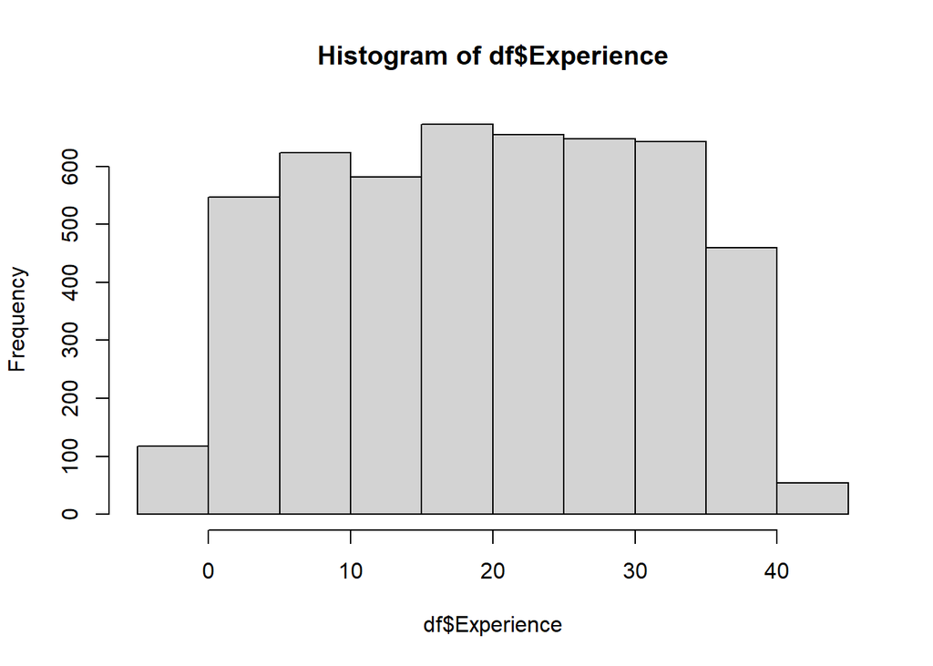

```r
hist(df$Experience) # checking density of the variable
```

We have 52 records that are not coherent with our data description, is it a small amount barely over 1% of over dataset. Still we do not want to lose information, if we were to delete those records we would give up 52*14 data points. What we will do is to replace those records with an experience value below 0 with the median value of the variable, which is 20.We choose the median because the mean would not be a round number and given that again the variable in recorded on a yearly basis, that would just be not appropriate.

```r
df$Experience[df$Experience <0] <- 20 # replace with the median
summary(df$Experience<0) # checking we have no smaller than 0 values
```

```
##    Mode   FALSE
## logical    5000
```

```r
df$Education.1 <- ifelse(df$Education == 1, 1, 0) # dummy for education=1
df$Education.2 <- ifelse(df$Education == 2, 1, 0) # dummy for education=2
df$Education.3 <- ifelse(df$Education == 3, 1, 0) #dummy for education=3
df2<-as.data.frame(df[,-c(1,5,8)]) # we get rid of the old education variable, column 8, the zip code, and the costumers ID
# the latter cannot be used as predictors
df2$Personal.Loan <- as.factor(df2$Personal.Loan) # we set it as factor because we want to classify by this variable
# the cl argument in the knn function requires a factor
str(df2) # structure of new data frame
```

```
## 'data.frame':    5000 obs. of  14 variables:
##  $ Age          : int  25 45 39 35 35 37 53 50 35 34 ...
##  $ Experience   : num  1 19 15 9 8 13 27 24 10 9 ...
##  $ Income       : int  49 34 11 100 45 29 72 22 81 180 ...
##  $ Family       : int  4 3 1 1 4 4 2 1 3 1 ...
##  $ CCAvg        : num  1.6 1.5 1 2.7 1 0.4 1.5 0.3 0.6 8.9 ...
##  $ Mortgage     : int  0 0 0 0 0 155 0 0 104 0 ...
##  $ Personal.Loan: Factor w/ 2 levels "0","1": 1 1 1 1 1 1 1 1 1 2 ...
##  $ Sec.acc      : int  1 1 0 0 0 0 0 0 0 0 ...
##  $ CD.acc       : int  0 0 0 0 0 0 0 0 0 0 ...
##  $ Online       : int  0 0 0 0 0 1 1 0 1 0 ...
##  $ CreditCard   : int  0 0 0 0 1 0 0 1 0 0 ...
##  $ Education.1  : num  1 1 1 0 0 0 0 0 0 0 ...
##  $ Education.2  : num  0 0 0 1 1 1 1 0 1 0 ...
##  $ Education.3  : num  0 0 0 0 0 0 0 1 0 1 ...
```

```r
dim(df2) #dimensions
```

```
## [1] 5000   14
```

We do not need the customer zip code ad the ID, so we drop those variables. Education has been turned into a dummy variable, in this case because we will be using a non-parametric method we can keep all three of them without risking to incur into multi-collinearity problems.

```r
set.seed(1) # to randomly select the records that will make up the samples, and get the same samples when we re-run the code
training<- sample(row.names(df2), 0.6*dim(df2)[1]) # 60% of records makeup the training set
validation <- setdiff(row.names(df2), training ) # 40% the validation set, all records not previously sorted in the training set
train.df<- df2[training,] #in data.frame format
valid.df<- df2[validation,] #in data.frame format
```

We have our dataframes for the training set and validation set.

### 7.2.a

We now standardize the data:

```r
train.stand.df <- train.df #initialize new variables, for the training set
valid.stand.df <- valid.df #for the validation set
stand.values <- preProcess(train.df[, c(1:6)], method=c("center", "scale")) # pre-processing, for the needed coefficients from training set
# method center subtract the mean of the numerical predictors data from the predictors value
# method scale divides by the standard deviation
#stand.values contains the coefficients drawn from the training set that we the use to then standardize our sets
train.stand.df[, c(1:6)] <- predict(stand.values, train.df[, c(1:6)]) # we consider the numerical variables in our data set
valid.stand.df[, c(1:6)]<-  predict(stand.values, valid.df[, c(1:6)]) # we apply the coefficients on validation set
```

we have standardized our data, taking the needed coefficients (means and SDs) from the training set and with those we standardize our training set and our validation set.In this process we do not standardize our 0,1 variables.

Introduction of a new record, new customer:

```r
new.customer<- data.frame(Age= 40, Experience = 10, Income= 84, Family= 2, CCAvg= 2,  Mortgage= 0,  Sec.acc=0 , CD.acc=0,  Online= 1 , CreditCard=1, Education.1= 0,Education.2= 1,
                          Education.3 =0) # we introduce new record in data.frame format

new.stand.df <- new.customer # initialize the standardized variable
new.stand.df[, c(1:6)] <- predict(stand.values, new.customer[, c(1:6)]) #use previously computed coefficients on numerical variables

nn <- knn(train = train.stand.df[,-7], test = new.stand.df, #training set and the new record
         cl = train.stand.df[, 7], k = 1, prob=TRUE) #training set as the factor of true classification

nn
```

```
## [1] 0
## attr(,"prob")
## [1] 1
## attr(,"nn.index")
##      [,1]
## [1,] 1104
## attr(,"nn.dist")
##           [,1]
## [1,] 0.5029812
## Levels: 0
```

This costumer is classified as non responsive to the loan advertisement campaign. The K nearest neighbor we found is non-respondant, by the majority rule the new record is as said before categorized as someone who would not take out a personal loan from the bank.

### 7.2.b

```r
accuracy.df <- data.frame(k=seq(1,20,1), accuracy=rep(0,20)) # set up table with the possible 20 values of k we are considering, and their respective accuracy measures

for (i in 1:20){
  knn.pred <- knn(train.stand.df[, -c(7)], valid.stand.df [, -c(7)], # knn classification for validation set from training set
                  cl= train.stand.df[,7], k=i)                        # factor of true classification taken from training set
  accuracy.df[i,2] <- confusionMatrix(knn.pred, valid.stand.df[,7])$overall[1] #compute accuracy for each of those k values
} # the $overall[1] argument selects the overall accuracy of the k of choice

kable(accuracy.df, row.names = F) %>% kable_paper("hover", "striped", full_width=T) #presentation of the accuracy table
```

| k | accuracy |
| --- | --- |
| 1 | 0.9595 |
| 2 | 0.9545 |
| 3 | 0.9610 |
| 4 | 0.9550 |
| 5 | 0.9575 |
| 6 | 0.9500 |
| 7 | 0.9545 |
| 8 | 0.9495 |
| 9 | 0.9545 |
| 10 | 0.9505 |
| 11 | 0.9520 |
| 12 | 0.9465 |
| 13 | 0.9500 |
| 14 | 0.9445 |
| 15 | 0.9470 |
| 16 | 0.9430 |
| 17 | 0.9460 |
| 18 | 0.9425 |
| 19 | 0.9430 |
| 20 | 0.9390 |

```r
# the hover and stripe arguments are style options
```

We are using both the training set and the validation set to find the optimal k, we chose to evalaute over a range of 0 to 20 as advised by the book. By choosing a a k that is too low we may risk to adapt too much to the noise of the data, on the contrary a too high value of it would be equivalent to just assign the new record to the prevalent class in the training set. K=3 seems to yield best performance, we select it as our k of choice.

### 7.2.c

```r
nn3v <- knn(train= train.stand.df[, -7], test= valid.stand.df[, -7], cl = train.stand.df[, 7], k = 3, prob = TRUE) #over the validation set
conf_matrix_k3<- confusionMatrix(nn3v, valid.stand.df[, 7], positive = "1") # build our confusion matrix, our positive outcome is loan=1
conf_matrix_k3$table #confusion matrix table
```

```
##           Reference
## Prediction    0    1
##          0 1790   73
##          1    5  132
```

```r
conf_matrix_k3$overall[1] # overall accuracy
```

```
## Accuracy
##    0.961
```

### 7.2.d

```r
nn3 <- knn(train = train.stand.df[,-7], test = new.stand.df,#training set, new standardized record
         cl = train.stand.df[, 7], k = 3, prob=TRUE) #re-classify the new record, but with k=3
                                                     # training set on new record

nn3 # recall the result
```

```
## [1] 0
## attr(,"prob")
## [1] 1
## attr(,"nn.index")
##      [,1] [,2] [,3]
## [1,] 1104 1187 1281
## attr(,"nn.dist")
##           [,1]      [,2]      [,3]
## [1,] 0.5029812 0.7233125 0.9775138
## Levels: 0
```

The client’s classification remains unchanged even if we used the best performing k.The Euclidian distances for the k 3 nearest neighbours are respectively 0.5029812, 0.7233125 and 0.9775138.

### 7.2.e

```r
set.seed(1)  # controlled random numbers, to have teh same samples when we re-run the code
training.e<- sample(row.names(df2), 0.5*dim(df2)[1]) #  training set 50% of the data
validation.e  <- sample(setdiff(row.names(df2), training ),  0.3*dim(df2)[1]) # validation set 30%
test.e <- setdiff(rownames(df2), union(training.e, validation.e)) #test set 20%
# we build all these sets as mutually exclusive

train.e.df<- df2[training.e,] # training set as individual data.frame
valid.e.df<- df2[validation.e,] # validation set as individual data.frame
test.e.df <- df2[test.e,] # test set as individual data.frame

train.estand.df <- train.e.df # initializing variables, for training set
valid.estand.df <-valid.e.df  # for validation set
test.estand.df <- test.e.df   # for test set

estand.values <- preProcess(train.e.df[, c(1:6)], method=c("center", "scale")) # pre-processing training set
# method center subtract the mean of the numerical predictors data from the predictors value
# method scale divides by the standard deviation
train.estand.df[, c(1:6)]<- predict(estand.values, train.e.df[, c(1:6)]) #training set, numerical variables
valid.estand.df[, c(1:6)]<-  predict(estand.values, valid.e.df[, c(1:6)]) #validation set, numerical values
test.estand.df[,c(1:6)] <- predict(estand.values, test.e.df[,c(1:6)]) #test set, numerical values


nn.e.tr <- knn(train = train.estand.df[,-7], test = train.estand.df[,-7] , cl = train.estand.df[, 7], k = 3, prob=TRUE)
#knn, training set on training set, with k=3
CF.TR<- confusionMatrix(nn.e.tr, train.estand.df[, 7], positive = "1") #positive outcome as loan=1, in training set
CF.TR$table # classification table
```

```
##           Reference
## Prediction    0    1
##          0 2266   54
##          1    2  178
```

```r
CF.TR$overall[1] #accuracy measure
```

```
## Accuracy
##   0.9776
```

```r
nn.e.val <- knn(train = train.estand.df[,-7], test = valid.estand.df[,-7] , cl = train.estand.df[, 7], k = 3, prob=TRUE)
#knn training set on validation set, with k=3
CF.VAL<- confusionMatrix(nn.e.val, valid.estand.df[, 7], positive = "1") #positive outcome as loan=1, in validation set
CF.VAL$table #classification table
```

```
##           Reference
## Prediction    0    1
##          0 1343   56
##          1    4   97
```

```r
CF.VAL$overall[1] #accuracy measure
```

```
## Accuracy
##     0.96
```

```r
nn.e.tt <- knn(train = train.estand.df[,-7], test = test.estand.df[,-7] , cl = train.estand.df[, 7], k = 3, prob=TRUE)
#knn training set on test set, with k=3
CF.TT<- confusionMatrix(nn.e.tt, test.estand.df[, 7], positive = "1") #positive outcome as loan=1, in test set
CF.TT$table #classification table
```

```
##           Reference
## Prediction   0   1
##          0 904  33
##          1   1  62
```

```r
CF.TT$overall[1] #accuracy measure
```

```
## Accuracy
##    0.966
```

```r
acc<- c( CF.TR$overall[1],CF.VAL$overall[1],CF.TT$overall[1]) # build a table with all the accuracy measures
miclass<- c(1-CF.TR$overall[1],1- CF.VAL$overall[1],1- CF.TT$overall[1])# the misclassification rate is 1-accuracy rate
table <- data.frame(acc, miclass) #dataframe with our rates
kable(table,row.names = T, col.names = c("Accuracy", "Mis-classification"))  %>%
  kable_paper("hover", "striped", full_width=T) %>% #to highlight the rows you are pointing at
  column_spec(1, bold = T, border_right = T) #style options
```

|  | Accuracy | Mis-classification |
| --- | --- | --- |
| 1 | 0.9776 | 0.0224 |
| 2 | 0.9600 | 0.0400 |
| 3 | 0.9660 | 0.0340 |

Over the training set we have selected our optimal k value, and we observe that over our new training set we maintain a good performance of k=3. The validation partition is used to appraise prediction performance, in fact previously we have used it to evaluate the mis-classification that our choice of k brought. There is not a big discrepancy between the two accuracy values for training set and validation set,this is good because in selecting the number of neighbors we did not over-fit over the data, meaning our k was not too low and we did not model over chance variation in the dataset. With the test set we assess how the model performs over a new set of data, its accuracy measure falls in between the other 2 sets which is also good simply because the k- nearest neighbor method is ding a good job at predicting classification. This is also due to the act that our K selection was done over 2 sets that were comprehensive of all data, so the test set in this case is not “new” data. Usually, the test set is new data and we expect for a lower accuracy measure. We present the mis-classification rates as well, if we take a look at the confusion matrices we printed out we can see that in all cases the better prediction works best for the class loan =0 which is the predominant class. As previously mentioned it is to be expected that the classic 0.5 cut-off would work best on the majority feature.